# Unveiling Journal to the West(西游记): Text Analysis Using R

June 24, 2024

## Journal to the West

- Journey to the West is regarded as one of the greatest Classic Chinese Novels
- It has also been described as arguably the most popular literary work in East Asia.
- Written by Wu Cheng'en, a novelist and poet of the Ming dynasty (1368–1644).
- 100 chapters, which can be divided into 3 main parts
- The first 7 chapters deal with the birth of a monkey, Sun Wukong, from a stone egg and his acquisition of magic powers.
- The next 5 chapters describe the story of a monk named Tang Sanzang, and the origin of his mission to the West.
- The bulk of the novel recounts the 81 adventures that befall Tang Sanzang and his entourage of three animal spirits on their journey to India, in search of Buddhist Sutras

## Goals

- Analyze the frequency and usage of words
- Analyze the sentiment

## Method

- Collect text data
- Preprocess the text data (cleaning, tokenization).
- Perform word frequency analysis
- Perform sentiment analysis

## Text data: Raw

[output not shown]

## Text data: Dataframe

| line | text |
| --- | --- |
| 1 | [西游记 / 吴承恩（明） 著 ] |
| 2 |  |
| 3 | 书籍介绍: |
| 4 | 《西游记》以丰富瑰奇的想象描写了师徒四众在迢遥的西方途上和穷山恶水冒险斗争的历程，并将所经历的千难万险形象化为妖魔鬼怪所设置的八十一难，以动物幻化的有情的精怪生动地表现了无情的山川的险阻，并以降妖服怪歌赞了取经人排除艰难的战斗精神，小说是人战胜自然的凯歌。 |
| 5 |  |
| 6 | ------章节内容开始------- |
| 7 |  |
| 8 | 上卷 第一回 灵根育孕源流出 心性修持大道生 |
| 9 | 本章字数:7529 |
| 10 |  |

## Text data: Tidy

```
## Rows: 448,161
## Columns: 2
## $ line <int >1, 1, 1, 1, 1, 1, 1, 3, 3, 4, 4, 4, 4, 4, 4, 4, 4, 4, 4, 4, 4, 4,…
## $ word <chr >"西 ", "游记 ", "吴 ", "承 ", "恩 ", "明 ", "著 ", "书籍 ", "介绍 ", "西 ",…
```

| line | word |
| --- | --- |
| 1 | 西 |
| 1 | 游记 |
| 1 | 吴 |
| 1 | 承 |
| 1 | 恩 |
| 1 | 明 |
| 1 | 著 |
| 3 | 书籍 |
| 3 | 介绍 |
| 4 | 西 |

## Chinese Word Segmentation

- Unlike English, where each word token is delimited by white spaces, Chinese word tokens are much less straightforward. A word, however, is an important semantic unit in many linguistic analysis.
- Chinese word `cutter` `jiebaR`

| line | word |
| --- | --- |
| 1 | 西游记 |
| 1 | 吴承恩 |
| 1 | 明 |
| 1 | 著 |
| 3 | 书籍 |
| 3 | 介绍 |
| 4 | 西游记 |
| 4 | 丰富 |
| 4 | 瑰奇 |
| 4 | 想象 |

## Word frequencies

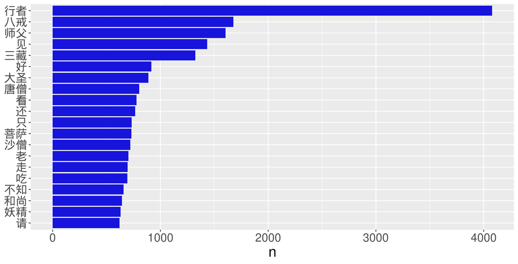

## Wordcloud

[interactive chart not shown]

## Sentiment analysis

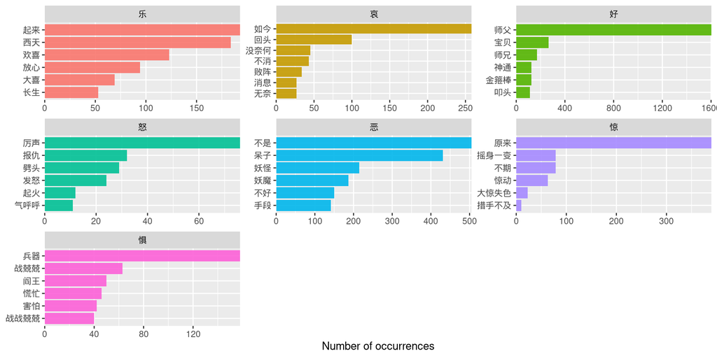

## Track sentiment in book

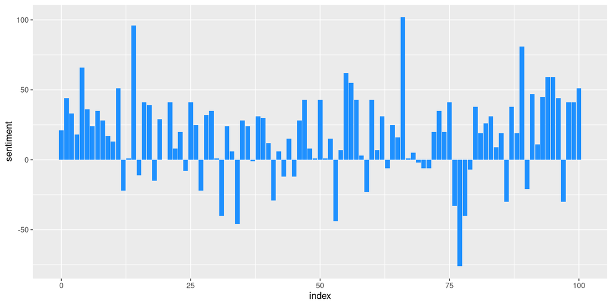

## Summary

- Segmentation of Chinese words
- Word frequency analysis: most common words in the book
- Sentiment analysis